# Lab 01: NathanI’s Hot-Dog Eating Content

Yihua Hu

4/1/2020

# 1 Workflow for Lab 01

The lab instructions can be found [here](https://stevenbedrick.github.io/data-vis-labs-2020/01-eda_hot_dogs.html); we will work through its contents together via Webex. You will use this RMarkdown file as your workspace and final document. Don’t forget to update the “author” metadata field at the top of the file!

# 2 Start by Loading Libraries

# 3 Loading and wrangling data

## 3.1 Loading

*Tip*: The data files for this lab are already loaded into this project, under the `data/` directory.

```r
hot_dogs <- read_csv(here::here("data","hot_dog_contest.csv"),
                     col_types=cols(gender=col_factor(levels=NULL)))
glimpse(hot_dogs)
```

```
Observations: 49
Variables: 4
$ year      <dbl> 2017, 2017, 2016, 2016, 2015, 2015, 2014, 2014, 2013, 2013,…
$ gender    <fct> male, female, male, female, male, female, male, female, mal…
$ name      <chr> "Joey Chestnut", "Miki Sudo", "Joey Chestnut", "Miki Sudo",…
$ num_eaten <dbl> 72.000, 41.000, 70.000, 38.000, 62.000, 38.000, 61.000, 34.…
```

## 3.2 Wrangling

Filtering and indicator field

```r
hot_dogs <- hot_dogs %>%
  mutate(post_ifoce = year >= 1997) %>%
  filter(year >= 1981 & gender == 'male')
hot_dogs
```

```
# A tibble: 37 x 5
    year gender name           num_eaten post_ifoce
   <dbl> <fct>  <chr>              <dbl> <lgl>
 1  2017 male   Joey Chestnut         72 TRUE
 2  2016 male   Joey Chestnut         70 TRUE
 3  2015 male   Matthew Stonie        62 TRUE
 4  2014 male   Joey Chestnut         61 TRUE
 5  2013 male   Joey Chestnut         69 TRUE
 6  2012 male   Joey Chestnut         68 TRUE
 7  2011 male   Joey Chestnut         62 TRUE
 8  2010 male   Joey Chestnut         54 TRUE
 9  2009 male   Joey Chestnut         68 TRUE
10  2008 male   Joey Chestnut         59 TRUE
# … with 27 more rows
```

# 4 Initial Plot

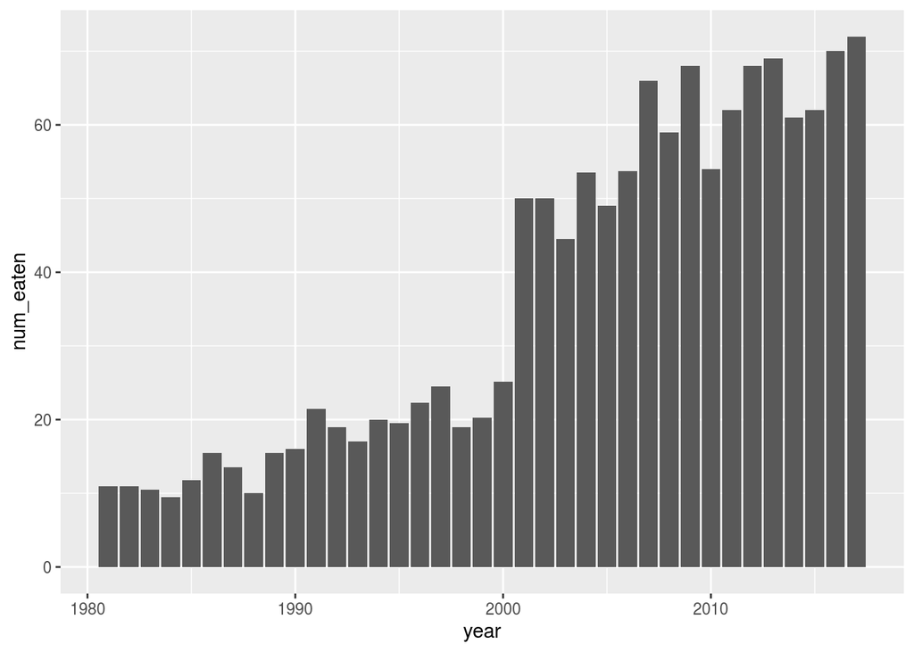

```r
ggplot(hot_dogs, aes(x = year, y = num_eaten)) +
  geom_col()
```

# 5 Axis Labels & Title

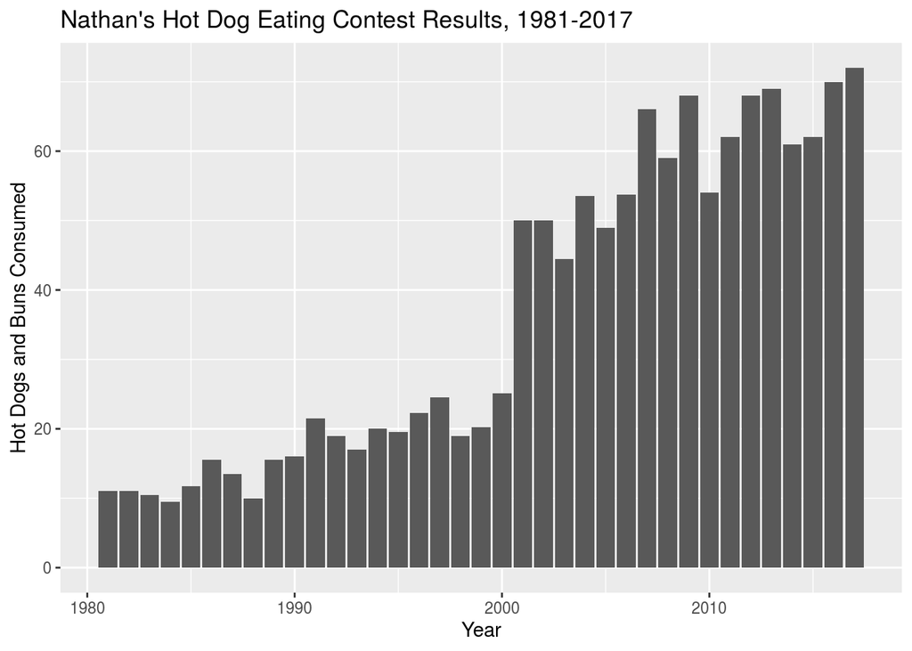

```r
ggplot(hot_dogs, aes(x = year, y = num_eaten)) +
  geom_col() +
  labs(x = "Year", y = "Hot Dogs and Buns Consumed") +
  ggtitle("Nathan's Hot Dog Eating Contest Results, 1981-2017")
```

# 6 Initial Colors & Styling

## 6.1 Challenge 1: 3 Different Versions

First, make all the columns outlined in “white”.

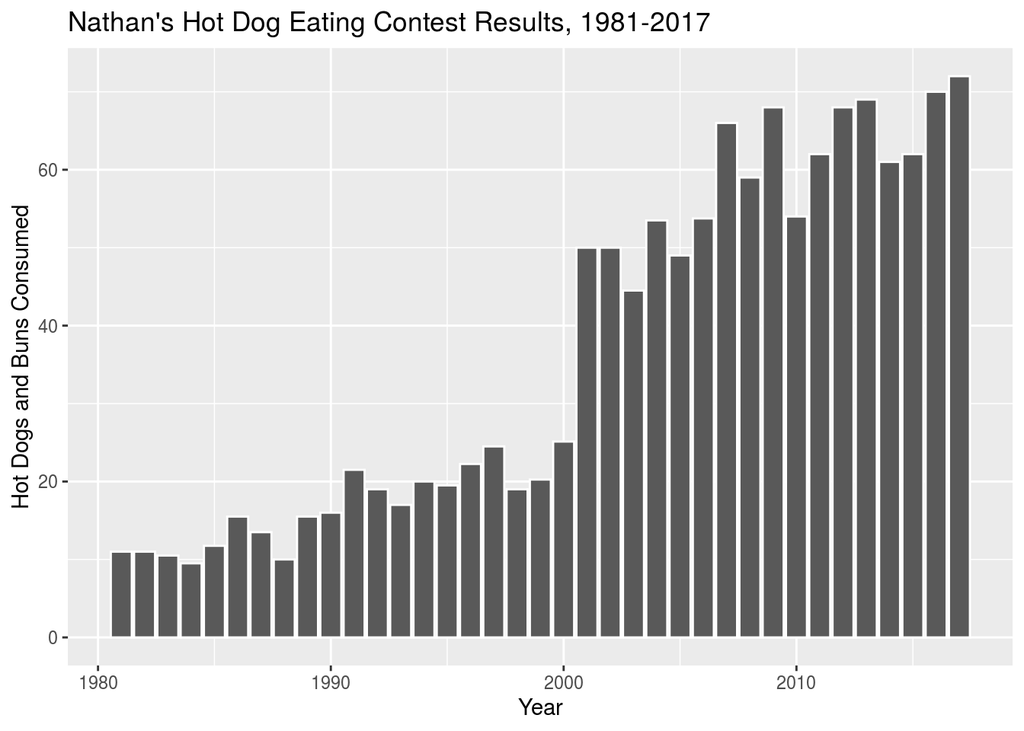

```r
ggplot(hot_dogs, aes(x = year, y = num_eaten)) +
  geom_col(colour = "white") +
  labs(x = "Year", y = "Hot Dogs and Buns Consumed") +
  ggtitle("Nathan's Hot Dog Eating Contest Results, 1981-2017")
```

Second, make all the columns outlined in “white” and filled in “lightblue” (I changed “navyblue” to “lightblue” because I prefer the latter.)

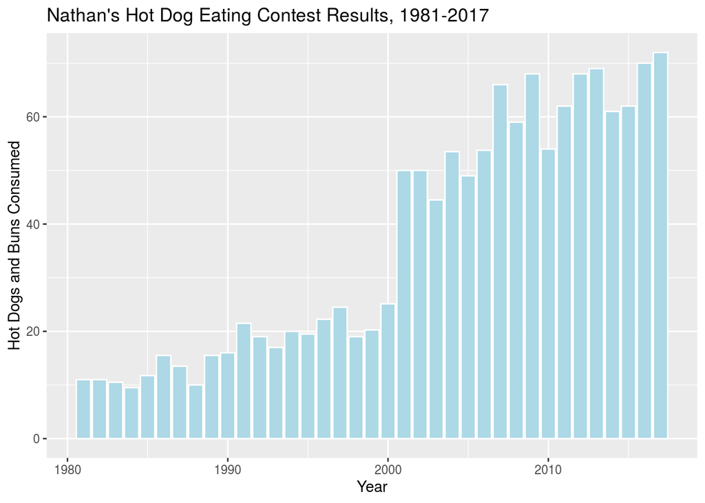

```r
ggplot(hot_dogs, aes(x = year, y = num_eaten)) +
  geom_col(colour = "white", fill = "lightblue") +
  labs(x = "Year", y = "Hot Dogs and Buns Consumed") +
  ggtitle("Nathan's Hot Dog Eating Contest Results, 1981-2017")
```

Third, make all the columns outlined in “white” and filled in according to whether or not post_ifoce is TRUE or FALSE (use default colors for now).

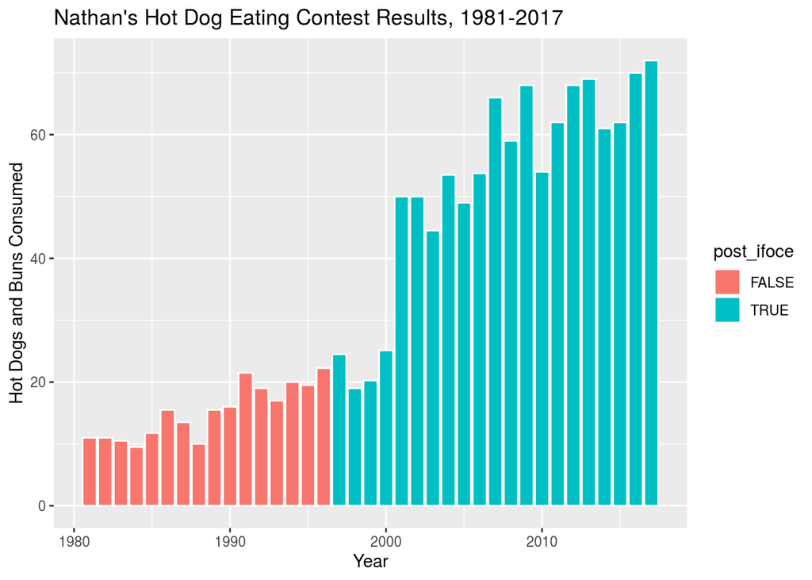

```r
ggplot(hot_dogs, aes(x = year, y = num_eaten)) +
  geom_col(aes(fill = post_ifoce), colour = "white") +
  labs(x = "Year", y = "Hot Dogs and Buns Consumed") +
  ggtitle("Nathan's Hot Dog Eating Contest Results, 1981-2017")
```

## 6.2 Challenge 2: Adjusting the Legend

Delete the legend title and make the legend text either “Post-IFOCE” or “Pre-IFOCE”.

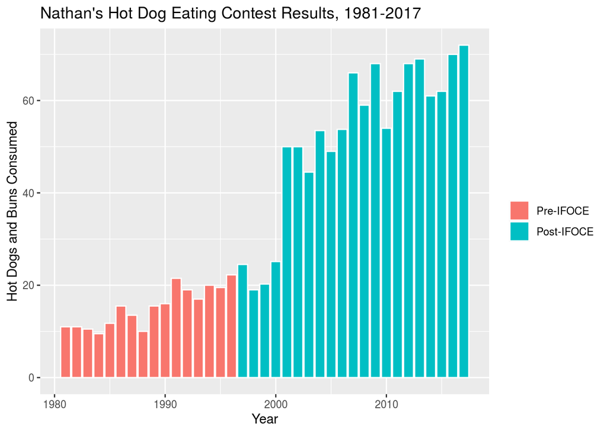

```r
ggplot(hot_dogs, aes(x = year, y = num_eaten)) +
  geom_col(aes(fill = post_ifoce), colour = "white") +
  labs(x = "Year", y = "Hot Dogs and Buns Consumed") +
  ggtitle("Nathan's Hot Dog Eating Contest Results, 1981-2017") +
  scale_fill_discrete(name = "",
                      labels=c("Pre-IFOCE", "Post-IFOCE"))
```

# 7 Change the Dataset

IFOCE affiliation analysis

## 7.1 Challenge 3: Adding Columns, Filtering

```r
hdm_affil <- read_csv(here::here("data", "hot_dog_contest_with_affiliation.csv"),
    col_types = cols(
      affiliated = col_factor(levels = NULL),
      gender = col_factor(levels = NULL)
      )) %>%
  mutate(post_ifoce = year >= 1997) %>%
  filter(year >= 1981 & gender == "male")
glimpse(hdm_affil)
```

```
Observations: 37
Variables: 6
$ year       <dbl> 2017, 2016, 2015, 2014, 2013, 2012, 2011, 2010, 2009, 2008…
$ gender     <fct> male, male, male, male, male, male, male, male, male, male…
$ name       <chr> "Joey Chestnut", "Joey Chestnut", "Matthew Stonie", "Joey …
$ num_eaten  <dbl> 72.000, 70.000, 62.000, 61.000, 69.000, 68.000, 62.000, 54…
$ affiliated <fct> current, current, current, current, current, current, curr…
$ post_ifoce <lgl> TRUE, TRUE, TRUE, TRUE, TRUE, TRUE, TRUE, TRUE, TRUE, TRUE…
```

## 7.2 Challenge 4: EDA

Use dplyr::distinct to figure out how many unique values there are of affiliated.

```r
hdm_affil %>%
  distinct(affiliated)
```

```
# A tibble: 3 x 1
  affiliated
  <fct>
1 current
2 former
3 not affiliated
```

Use dplyr::count to count the number of rows for each unique value of affiliated.

```r
hdm_affil %>%
  count(affiliated, sort = TRUE)
```

```
# A tibble: 3 x 2
  affiliated         n
  <fct>          <int>
1 not affiliated    20
2 current           11
3 former             6
```

## 7.3 Updated Plot

Now plot this new data, and fill the columns according to our new affiliated column.

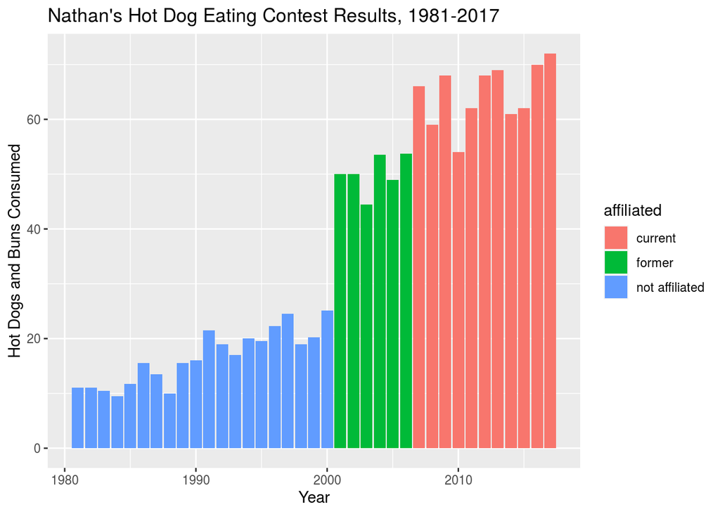

```r
ggplot(hdm_affil, aes(x = year, y = num_eaten)) +
  geom_col(aes(fill = affiliated)) +
  labs(x = "Year", y = "Hot Dogs and Buns Consumed") +
  ggtitle("Nathan's Hot Dog Eating Contest Results, 1981-2017")
```

## 7.4 Challenge 5: Adjusting the Colors

Update the colors using hex colors: c(‘#E9602B’,‘#2277A0’,‘#CCB683’), change the legend title to “IFOCE-affiliation”, and save this plot object as “affil_plot”.

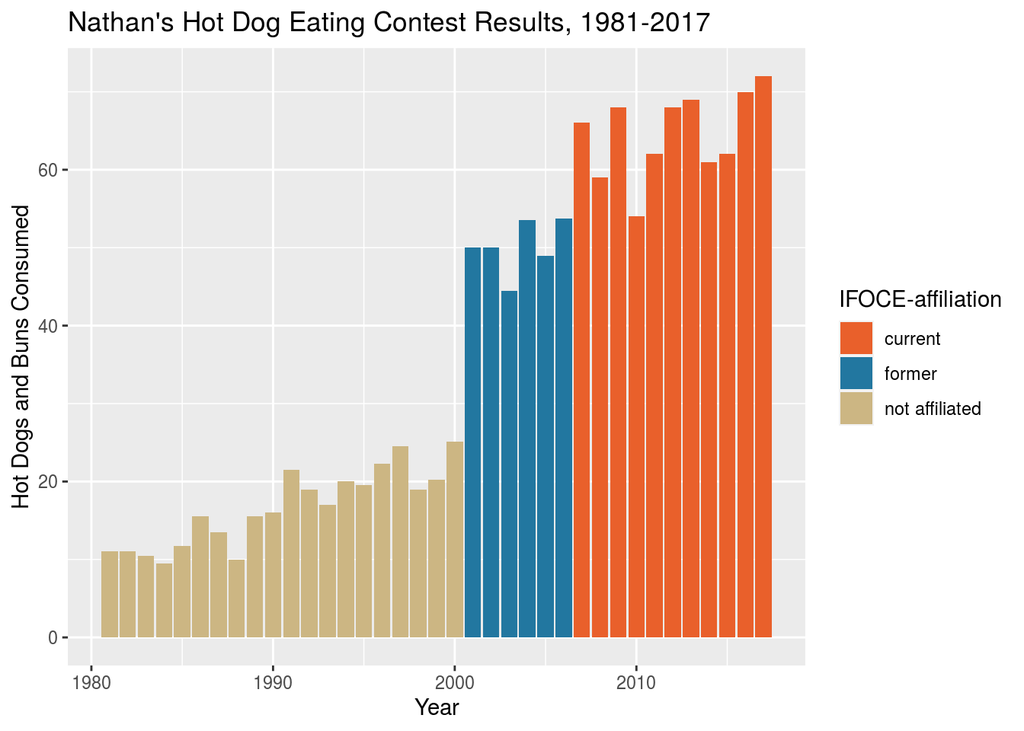

```r
affil_plot <- ggplot(hdm_affil, aes(x = year, y = num_eaten)) +
  geom_col(aes(fill = affiliated)) +
  labs(x = "Year", y = "Hot Dogs and Buns Consumed") +
  ggtitle("Nathan's Hot Dog Eating Contest Results, 1981-2017") +
  scale_fill_manual(values = c('#E9602B','#2277A0','#CCB683'),
                    name = "IFOCE-affiliation")
affil_plot
```

# 8 Sweating the Details

## 8.1 Initial plot

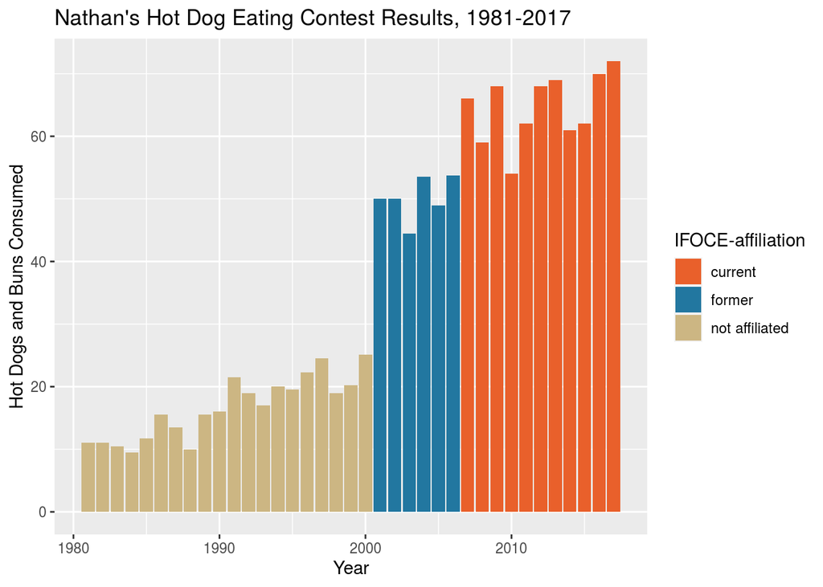

```r
affil_plot
```

## 8.2 Challenge 6: Custom Axes

Tighten scales and coordinates up.

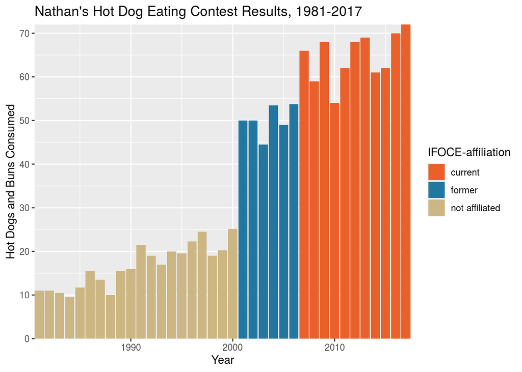

```r
affil_plot <- affil_plot +
  scale_y_continuous(expand = c(0, 0),
                     breaks = seq(0, 70, 10)) +
  scale_x_continuous(expand = c(0, 0))
affil_plot
```

loosen things up a bit by setting the x-axis range to 1980-2018 and the y-axis range to 0-80.

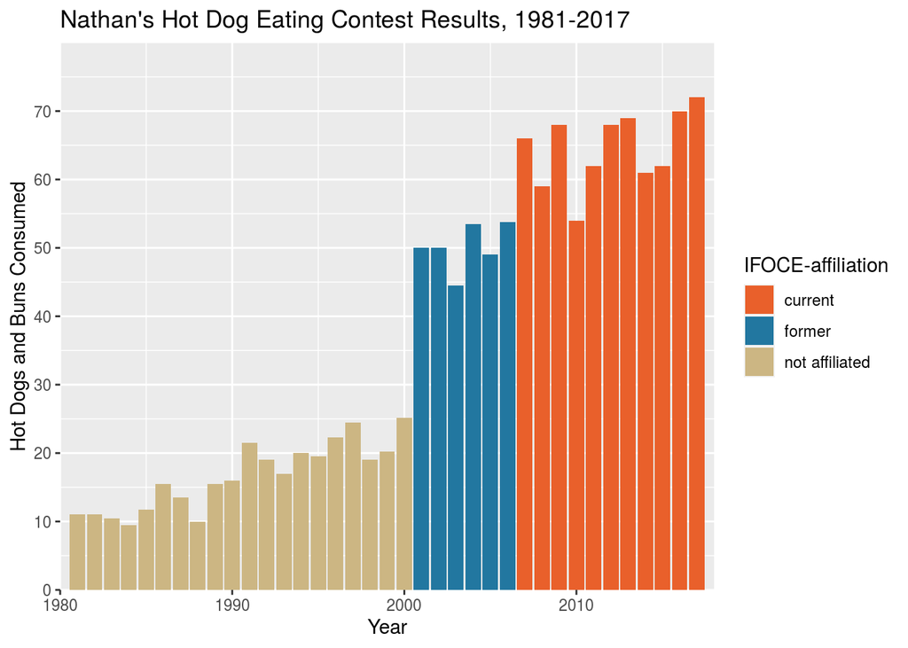

```r
affil_plot <- affil_plot +
  coord_cartesian(xlim = c(1980, 2018), ylim = c(0, 80))
affil_plot
```

# 9 Themes

## 9.1 Initial Plot

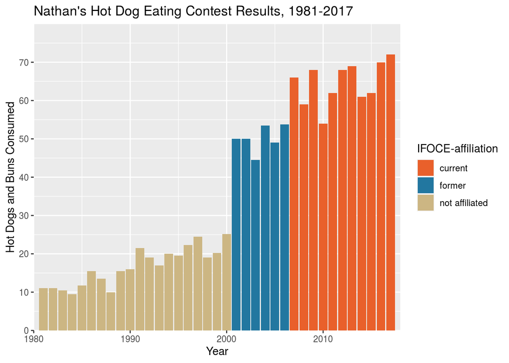

```r
affil_plot
```

## 9.2 Making a Custom Theme

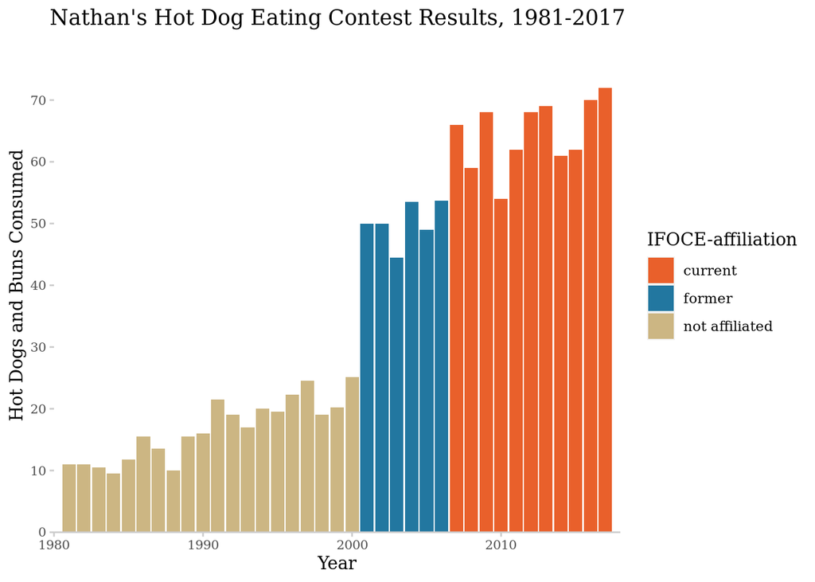

```r
hot_diggity<- theme(plot.title = element_text(hjust = 0.5)) +
  theme(axis.text = element_text(size =8)) +
  theme(panel.background = element_blank())+
  theme(axis.line.x = element_line(color = "gray80",size=0.5)) +
  theme(axis.ticks = element_line(color = "gray80",size = 0.5)) +
  theme(text=element_text(family = "Georgia"))
affil_plot + hot_diggity
```

## 9.3 Applying Library Themes

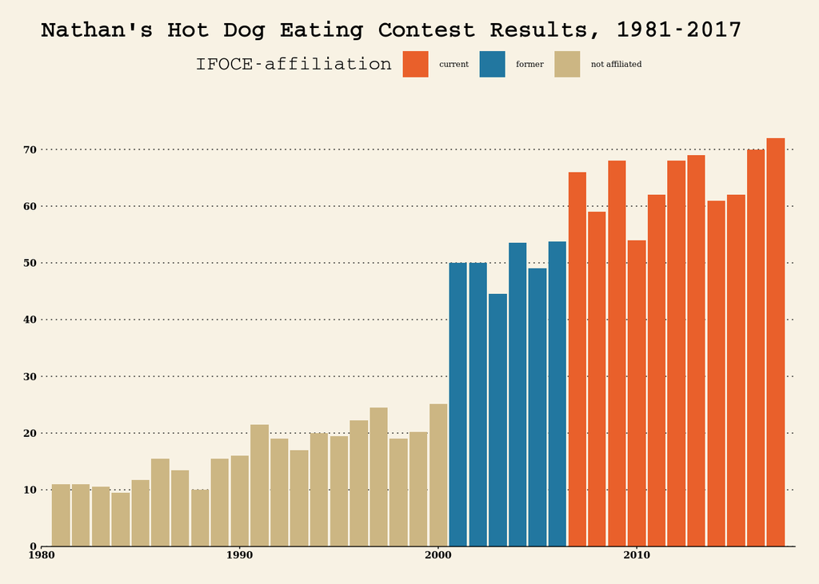

```r
affil_plot + theme_wsj(base_family = "Georgia",base_size = 6)
```

## 9.4 Custom Tick Marks & Labels

Mess with the x-axis ticks and labels.

```r
years_to_label <- seq(from = 1981, to = 2017, by=6)
hd_years <- hdm_affil %>%
  distinct(year) %>%
  mutate(year_lab = ifelse(year %in% years_to_label,year,""))
```

# 10 Finalizing Our Masterpiece!

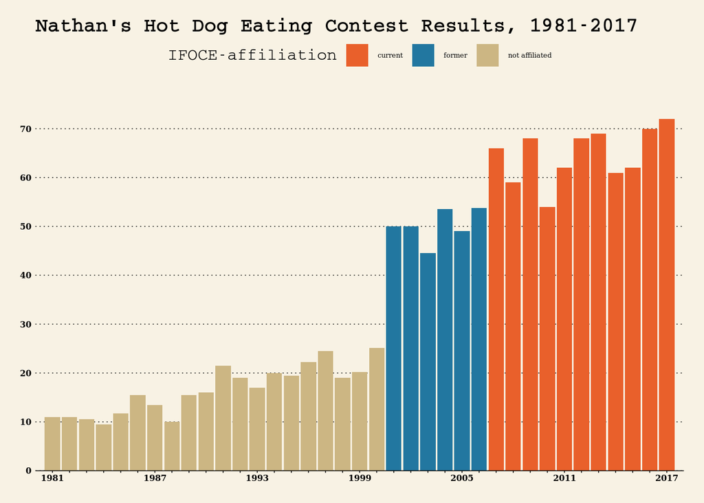

```r
nathan_plot <- affil_plot +
  theme_wsj(base_size = 6, base_family = "Georgia") +
  scale_x_continuous(expand =c(0,0),
                     breaks = hd_years$year,
                     labels = hd_years$year_lab)
nathan_plot
```

## 10.1 Adding Custom Annotations

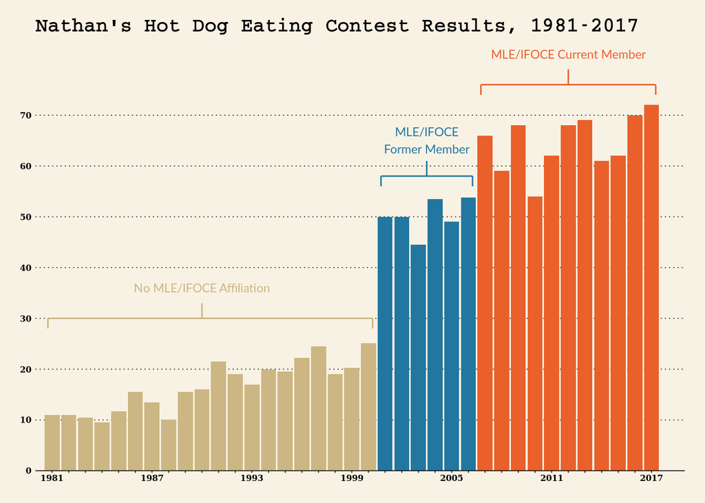

```r
nathan_ann <- nathan_plot +
  guides(fill=FALSE)+
  coord_cartesian(xlim=c(1980, 2019),ylim=c(0,85)) +
  annotate('segment', x = 1980.75, xend = 2000.25, y = 30, yend = 30, size = 0.5, color = '#CCB683') +
  annotate('segment', x = 1980.75, xend = 1980.75, y = 30, yend = 28, size = 0.5, color = '#CCB683') +
  annotate('segment', x = 2000.25, xend = 2000.25, y = 30, yend = 28, size = 0.5, color = '#CCB683') +
  annotate('segment', x = 1990, xend = 1990, y = 33, yend=30, size = 0.5, color = '#CCB683') +
  annotate('text', x=1990, y=36, label="No MLE/IFOCE Affiliation", color="#CCB683", family="Lato", hjust=0.5, size = 3) +
  annotate('segment', x=2000.75, xend=2006.25, y= 58, yend=58, size=0.5, color="#2277A0") +
  annotate('segment', x=2000.75, xend=2000.75, y= 58, yend=56, size=0.5, color="#2277A0") +
  annotate('segment', x=2006.25, xend=2006.25, y= 58, yend=56, size=0.5, color="#2277A0") +
  annotate('segment', x=2003.5, xend=2003.5, y= 61, yend=58, size=0.5, color="#2277A0") +
  annotate('text', x=2003.5, y=65, label="MLE/IFOCE\nFormer Member", color="#2277A0", family="Lato", hjust=0.5, size = 3) +
  annotate('segment', x=2006.75, xend=2017.25, y= 76, yend=76, size=0.5, color="#E9602B") +
  annotate('segment', x=2006.75, xend=2006.75, y= 76, yend=74, size=0.5, color="#E9602B") +
  annotate('segment', x=2017.25, xend=2017.25, y= 76, yend=74, size=0.5, color="#E9602B") +
  annotate('segment', x=2012, xend=2012, y= 79, yend=76, size=0.5, color="#E9602B") +
  annotate('text', x=2012, y=82, label="MLE/IFOCE Current Member", color="#E9602B", family="Lato", hjust=0.5, size = 3)
nathan_ann
```

## 10.2 Adding an Additional Data Layer

First, load data and filter it to obtain data from female contestants.

```r
hdm_females <- read_csv(here::here("data", "hot_dog_contest_with_affiliation.csv"),
    col_types = cols(
      affiliated = col_factor(levels = NULL),
      gender = col_factor(levels = NULL)
      )) %>%
  mutate(post_ifoce = year >= 1997) %>%
  filter(year >= 1981 & gender == "female")
glimpse(hdm_females)
```

```
Observations: 7
Variables: 6
$ year       <dbl> 2017, 2016, 2015, 2014, 2013, 2012, 2011
$ gender     <fct> female, female, female, female, female, female, female
$ name       <chr> "Miki Sudo", "Miki Sudo", "Miki Sudo", "Miki Sudo", "Sonya…
$ num_eaten  <dbl> 41.00, 38.00, 38.00, 34.00, 36.75, 45.00, 40.00
$ affiliated <fct> current, current, current, current, current, current, curr…
$ post_ifoce <lgl> TRUE, TRUE, TRUE, TRUE, TRUE, TRUE, TRUE
```

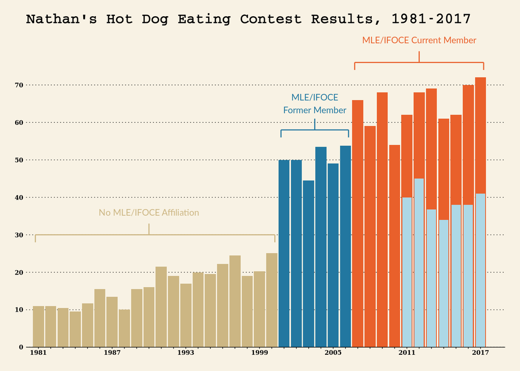

```r
nathan_w_females <- nathan_ann +
  # add in the female data, and manually set a fill color
  geom_col(data = hdm_females,
           width = 0.75,
           fill = "lightblue")
nathan_w_females
```

Add a final caption.

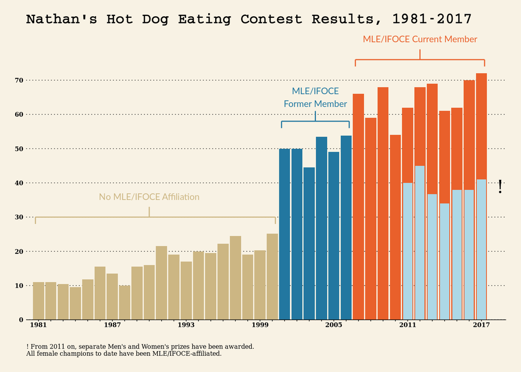

```r
caption <- paste(strwrap("! From 2011 on, separate Men's and Women's prizes have been awarded. All female champions to date have been MLE/IFOCE-affiliated.", 70), collapse="\n")

nathan_w_females +
  annotate('text', x = 2018.5, y = 39, label="!", family = "Georgia", size = 6) +
  labs(caption = caption) +
  theme(plot.caption = element_text(family = "Georgia", size=6, hjust=0, margin=margin(t=15)))
```